# PSY 8712 Week 8 Project

Delaney Ross

# **Reproducible Image and Online Resources:**

An image of this project as of *2026-03-22* can be accessed by [clicking this link.](https://mybinder.org/v2/gh/ross0778/psy8712-week8/HEAD)

An interactive web app is available by [clicking this link instead.](https://8d76t4-delaney-ross.shinyapps.io/shiny_week8/)

# **Script Settings and Resources**

```r
setwd(dirname(rstudioapi::getActiveDocumentContext()$path))
library(tidyverse)
```

# **Data Import and Cleaning**

This section imports and cleans the data file, converts times to POSIX format, converts condition and gender to factor, reverse codes q5, and finds row means for following calculations. I used mutate to make these conversions as it seemed the most efficient method and I subtracted q5 from the sum of the maximum and minimum of this question as it was the most straightforward way to reverse code the column.

```r
week8_tbl <- read.csv("../data/week3.csv") %>%
  mutate(
    timeStart = ymd_hms(timeStart),
    timeEnd = ymd_hms(timeEnd),
    condition = factor(condition,
                       levels = c("A", "B", "C"),
                       labels = c("Block A", "Block B", "Block C")),
    gender = factor(gender,
                    levels = c("M", "F"),
                    labels = c("Male", "Female")),
    q5 = (1 + 5) - q5,
    mq1q6 = rowMeans(pick(q1:q6)),
    mq8q10 = rowMeans(pick(q8:q10))
  )
```

# **Visualization**

This section displays the data from q1 through q6 as well as a scatterplot of the mean scores of q1 through q6 and the mean scores of q8 through q10. I used select to display the data contained within q1-q6, geom_point to create the scatterplot, and geom_smooth() in order to create the regression line.

```
##    q1 q2 q3 q4 q5 q6
## 1   5  4  4  1  2  1
## 2   2  4  3  1  3  1
## 3   5  5  2  1  5  1
## 4   4  3  4  2  4  1
## 5   3  1  3  5  2  1
## 6   4  3  2  3  3  1
## 7   2  4  1  3  1  1
## 8   4  2  5  1  1  1
## 9   2  5  3  4  2  1
## 10  3  4  2  4  5  1
## 11  5  2  3  1  5  1
## 12  3  1  3  5  4  1
## 13  5  5  2  3  4  1
## 14  1  3  5  4  2  1
```

[output cut: 35 more lines]

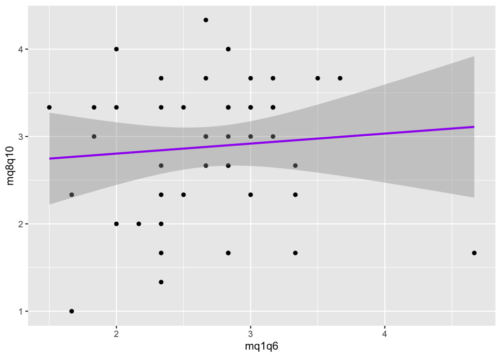

# **Analysis**

```
##
##  Pearson's product-moment correlation
##
## data:  week8_tbl$mq1q6 and week8_tbl$mq8q10
## t = 0.58309, df = 47, p-value = 0.5626
## alternative hypothesis: true correlation is not equal to 0
## 95 percent confidence interval:
##  -0.2012466  0.3574248
## sample estimates:
##        cor
## 0.08474575
```

# **Data Export**

This section exports a minimal version of the dataset that is appropriate for shiny. I used select() in orer to select only the necessary variables and write.csv() to export the data.

```r
week8_tbl %>%
  select(gender, timeEnd, mq1q6, mq8q10) %>%
  write.csv("../shiny_week8/week8_shiny.csv", row.names = FALSE)
```